# 218Y_brianamaro_A3

Brian Amaro

Transportation and buildings are two major sources of greenhouse gas emissions. As we look to understand the current and potential sustainability of the Bay Area, analyzing the vehicle and building emissions are a vital place to start.

For our analysis, we will be studying the zipcode of 94027, notably the location of Atherton, California. Earning the title of wealthiest town in America according to the Bloomberg Richest Places Index, the suburban town has an average household income of more than $450,000. This location was selected due to this wealth (there may be interesting implications from factors such as increased ability to adopt more expensive yet more sustainable technologies such as electric cars).

To analyze building emissions, we used PG&E data to track emissions due to residential and commercial electricity and gas usage from 2013 to 2019. In the raw data, there were a couple of issues that needed to be resolved. First, the 2017 Q4 data double-counted the September energy usage from Q3, which had to be filtered out in the aggregation step. Additionally, the labeling of the 2014 Gas Use data used a different name for the units, which needed to be changed to “TOTALTHM” to be combined with the other years. The electricity and gas energy use data were converted to giga-British Thermal Units (GBTU) for ease of comparison.

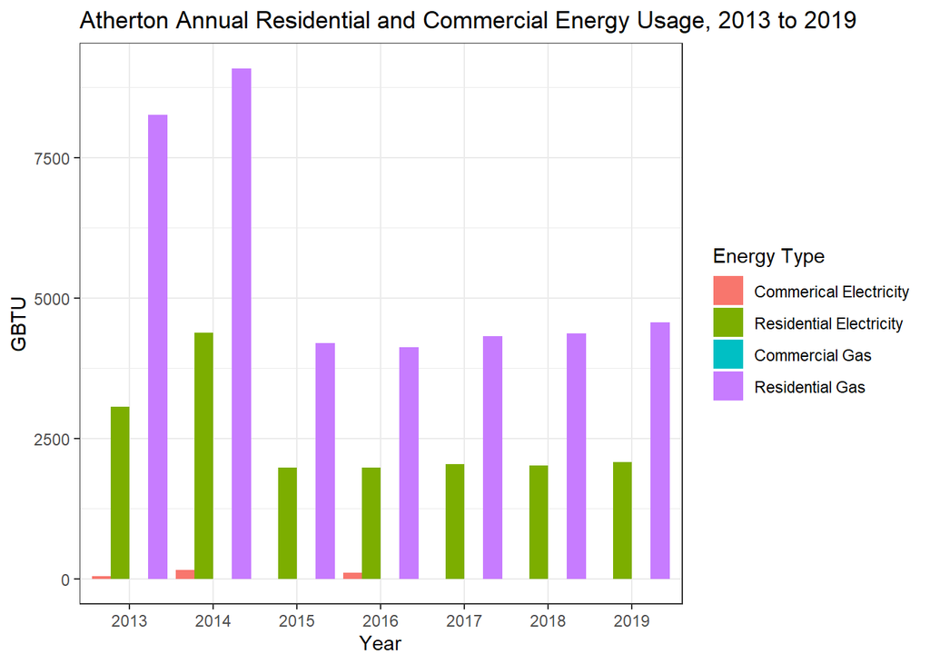

From the bar graph above, it is evident that Atherton’s energy usage is predominantly residential rather than commercial, with residential gas use consistently being significantly higher than residential electricity. Also, there was a sharp drop-off in residential energy use from 2014 to 2015, which is followed by a gradual increase in recent years. —

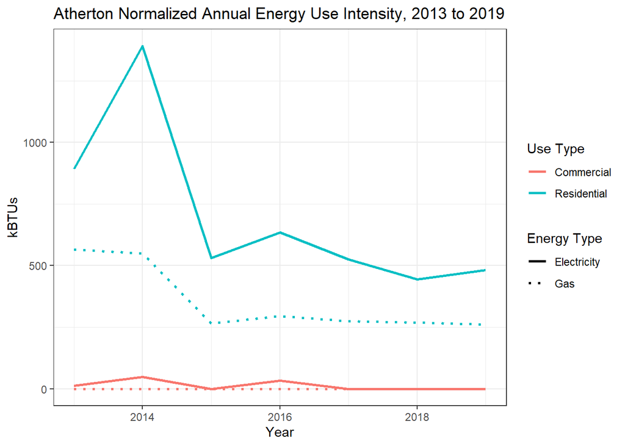

In this graph, residential gas is measured in KBTU per resident per HDD, residential electricity in KBTU per resident per CDD, commercial gas in KBTU/job/HDD, and commercial electricity in KBTU/job/CDD. In this normalized visualization, the stark contrast between residential and commercial energy usage persists. Moreover, the same drastic drop in residential energy usage from 2014 to 2015 exists. However, the gradual upward trend in residential gas and electricity use from 2016 to 2019 is no longer present.

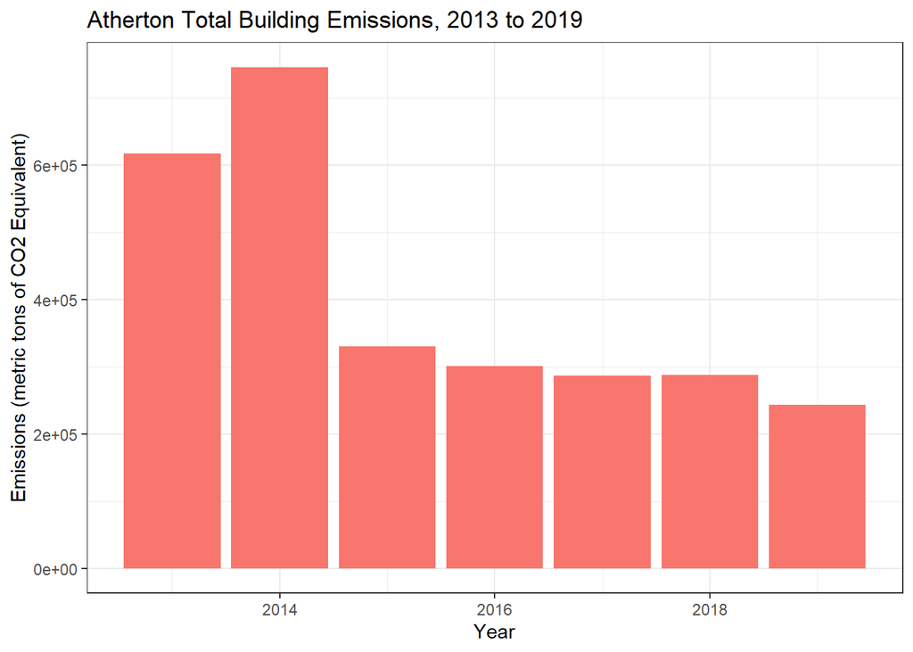

The above chart shows the total building emission for most of the past decade. One notable feature is the large drop after 2014 as otherwise building emissions have been relatively stable.

To analyze transportation emissions, we mapped commuter travel to and from Atherton using LODES data at the census block group level. For simplification purposes, we ignored internal trips. We know they are actually contributing to greenhouse gas emissions, but from a simplification perspective, they’re at the wrong scale. This is also reasonable as they made up less than 2% of all commuter trips between 2013 and 2019 as Atherton is quite small and wealthy. This was used to find the total miles traveled by vehicles which was matched with emissions rates data from the California Air Resources Board (CARB) Emission Factors (EMFAC) model to produce overall emission estimates. The final estimates appear to be slight underestimates as 4% of the CBGs appear to be having missing values.

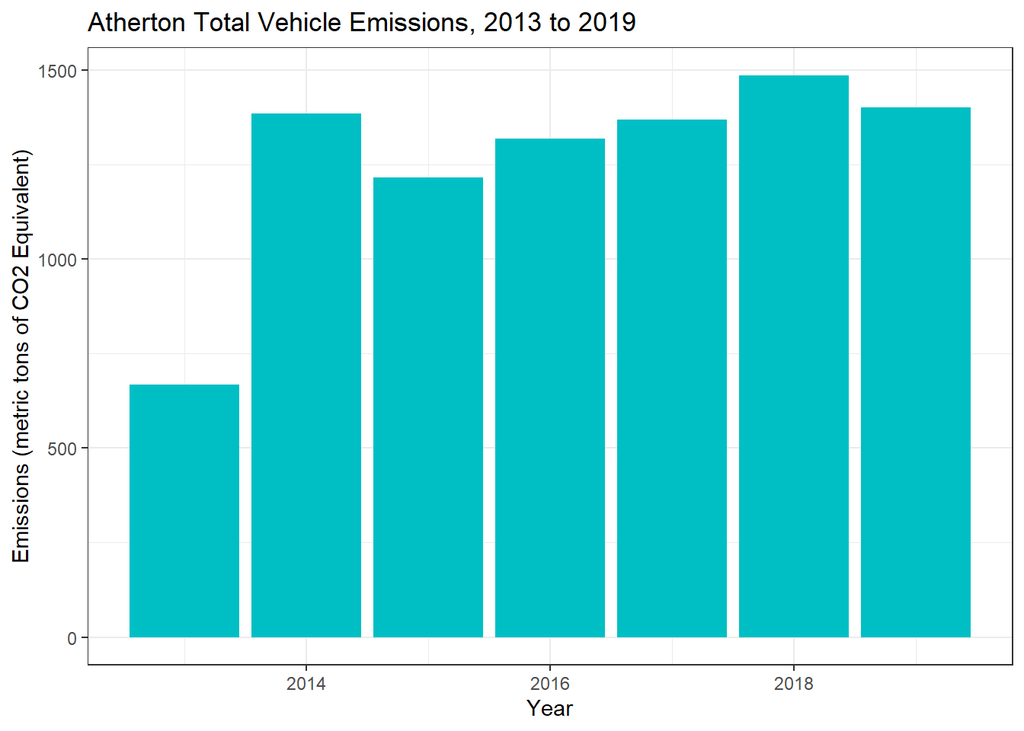

We can see in the chart above that vehicle emissions appeared to increase dramatically in 2014 and have stayed relatively constant afterwards. The magnitude of vehicle emissions is also quite low, which is in accordance with the characteristically small population of Atherton.

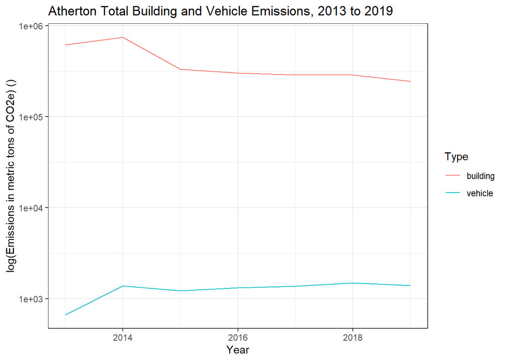

The chart above combines building and vehicle graphs with a log scale for emissions due to the difference in magnitudes. The most distinctive feature is how building emissions are much higher in Atherton, potentially related to its increased wealth.

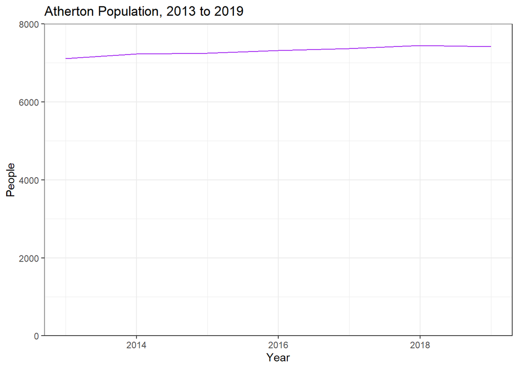

As can be seen from the chart above, population has been relatively stable with only a slight increase.

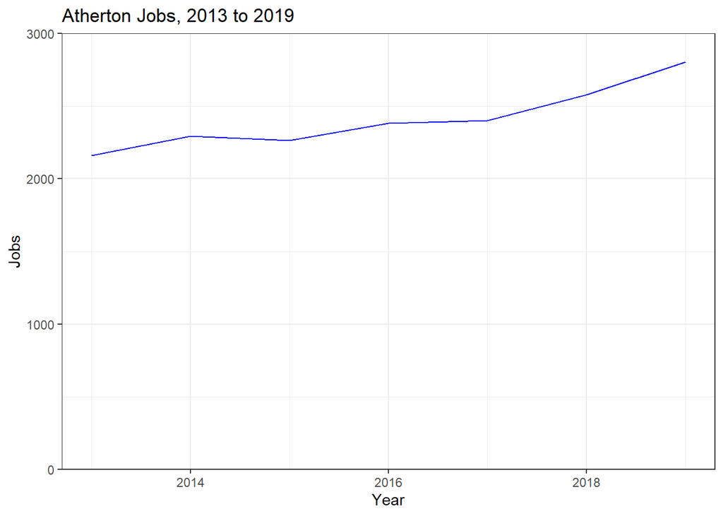

This chart above shows that the number of jobs, which is currently less than the population, is increasing, potentially creating more nearby opportunities so that residents do not need to commute outside of Atherton.

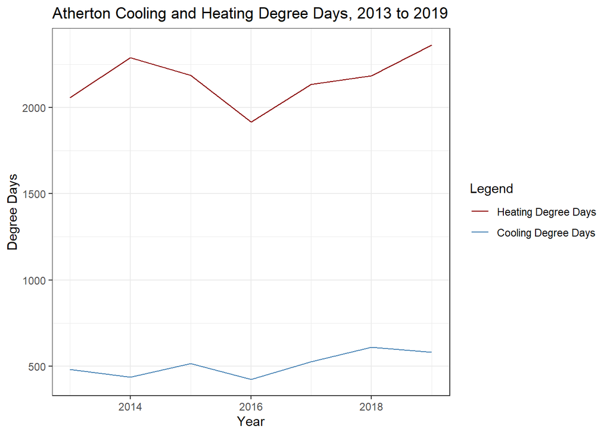

The chart above shows that the energy burden is slightly increasing in Atherton, particularly in recent years.

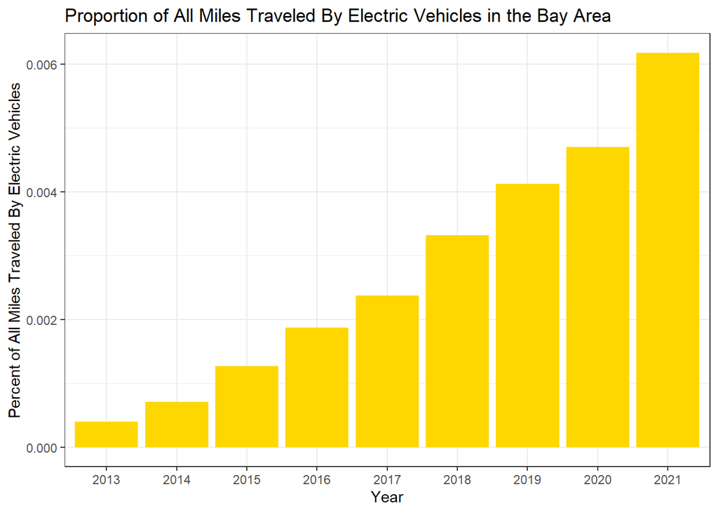

The chart above shows that electric vehicle adoption (represented by the proportion of miles driven by electric vehicles to all vehicles) is also increasing with implications of decreasing transportation emissions.

Other than the trend in heating and cooling degree days, this appears to be a hopeful indicator for the future of the Bay Area, but it is masqueraded by the fact of the overwhelming wealthiness of Atherton. Its population is unchanging mostly due to the fact that it is and has been extremely expensive to live there. The residents are likely senior employees/executives that are unlikely to have job mobility. While the electric vehicle adoption is indeed showing the trend for the overall Bay Area, it is still pretty low.

However, despite Atherton’s wealth, this analysis is still useful for the Bay Area as a whole. It shows the implications of how wealth (and its ability to make costs less important) affects the sustainability of a location. Atherton’s suburbanity also allowed us to focus on emissions from mostly residential sources, allowing us to essentially isolate that type of source.

Beyond this analysis, it is worth considering the design of potential GHG accounting methodologies. The main idea that has to be kept in mind when designing the GHG accounting methodology is that the problem trying to be solved, namely global warming, has widespread negative externalities as well as relatively high urgency. Thus, this is a scenario where we must focus on high impact, practical solutions. This is all mentioned as to justify the notion that political responsibility should be allocated mostly not on a moral responsibility basis, but on a more practical basis that will encourage solutions to the problems. Therefore my design for the GHG accounting methodology would focus on allocating responsibility in ways that effectively incentivize agents to be more sustainable, starting with the goal of reducing emissions from the largest sources. One example would be by accounting emissions by the location of the corporation headquarters. It would be up to the corporation based on how they wanted to distribute this cost on to customers, a decision ideally influenced by economic mechanisms of the free market. While this would have the corporation — the one fundamentally responsible for producing the product or service along with the resulting emissions — responsible for the decision, there is the more important factor that it is easier to hold a corporation responsible as it is one singular entity. Additionally, this would add a significant burden for the areas where these corporations are located, balancing the economic benefits of the jobs produced in these areas. This is to say that these areas would be able to and should sustain the potential economic costs from accounting emissions from the corporation there in exchange for all the economic benefits the corporation produces there.

While there is still plenty to be analyzed in the future of emissions, this analysis provides some key insights in the future of the Bay Area.